# IP_Week_14_PartB

```r
r <- cor (df4, use = "complete.obs")
round(r,2)
```

```
##                         Administrative Administrative_Duration Informational
## Administrative                    1.00                    0.60          0.38
## Administrative_Duration           0.60                    1.00          0.30
## Informational                     0.38                    0.30          1.00
## Informational_Duration            0.25                    0.24          0.62
## ProductRelated                    0.43                    0.29          0.37
## ProductRelated_Duration           0.37                    0.35          0.39
## BounceRates                      -0.21                   -0.14         -0.11
## ExitRates                        -0.31                   -0.20         -0.16
## PageValues                        0.10                    0.07          0.05
## SpecialDay                       -0.10                   -0.07         -0.05
## OperatingSystems                 -0.01                   -0.01         -0.01
## Browser                          -0.03                   -0.02         -0.04
## Region                           -0.01                   -0.01         -0.03
## TrafficType                      -0.03                   -0.02         -0.04
##                         Informational_Duration ProductRelated
## Administrative                            0.25           0.43
## Administrative_Duration                   0.24           0.29
## Informational                             0.62           0.37
## Informational_Duration                    1.00           0.28
## ProductRelated                            0.28           1.00
## ProductRelated_Duration                   0.35           0.86
## BounceRates                              -0.07          -0.19
## ExitRates                                -0.10          -0.29
## PageValues                                0.03           0.05
## SpecialDay                               -0.03          -0.03
## OperatingSystems                         -0.01           0.00
## Browser                                  -0.02          -0.01
## Region                                   -0.03          -0.04
## TrafficType                              -0.03          -0.04
##                         ProductRelated_Duration BounceRates ExitRates
## Administrative                             0.37       -0.21     -0.31
## Administrative_Duration                    0.35       -0.14     -0.20
## Informational                              0.39       -0.11     -0.16
## Informational_Duration                     0.35       -0.07     -0.10
## ProductRelated                             0.86       -0.19     -0.29
## ProductRelated_Duration                    1.00       -0.17     -0.25
## BounceRates                               -0.17        1.00      0.90
## ExitRates                                 -0.25        0.90      1.00
## PageValues                                 0.05       -0.12     -0.17
```

[output cut: 20 more lines]

```
##                         TrafficType
## Administrative                -0.03
## Administrative_Duration       -0.02
## Informational                 -0.04
## Informational_Duration        -0.03
## ProductRelated                -0.04
## ProductRelated_Duration       -0.04
## BounceRates                    0.09
## ExitRates                      0.09
## PageValues                     0.01
## SpecialDay                     0.05
## OperatingSystems               0.18
## Browser                        0.10
## Region                         0.04
## TrafficType                    1.00
```

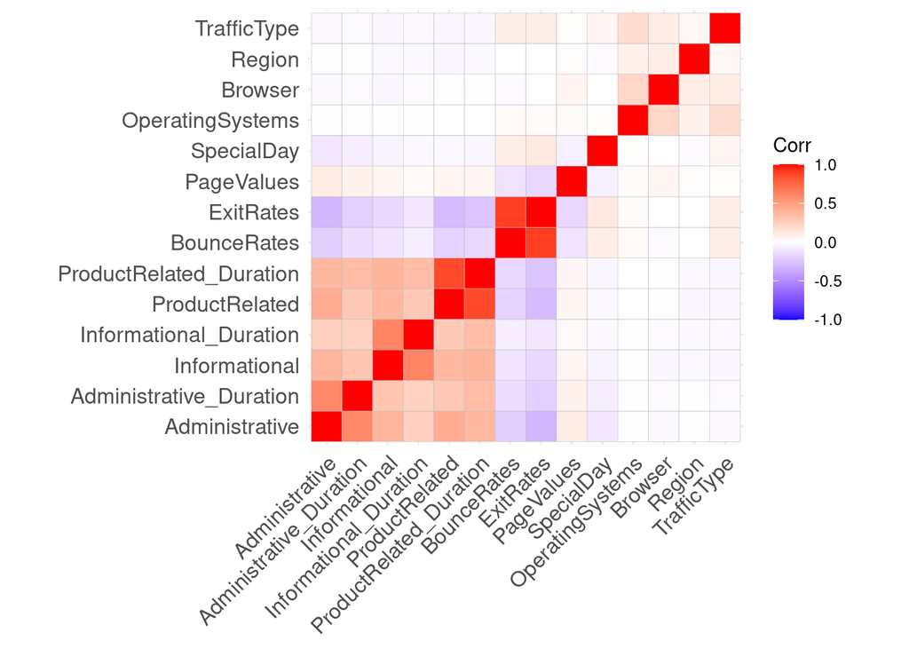

```r
install.packages("ggcorrplot")
library(ggplot2)
library(ggcorrplot)
ggcorrplot(r)
```

```r
#the correlations are generally week
```

```r
shopper <- new_df[, c(1,2,3,4,5,6,7,8,9,18)]
shopper.class <- new_df[,"Revenue"]
head(shopper)
```

```
##    Administrative Administrative_Duration Informational Informational_Duration
## 1:              0                       0             0                      0
## 2:              0                       0             0                      0
## 3:              0                      -1             0                     -1
## 4:              0                       0             0                      0
## 5:              0                       0             0                      0
## 6:              0                       0             0                      0
##    ProductRelated ProductRelated_Duration BounceRates ExitRates PageValues
## 1:              1                0.000000  0.20000000 0.2000000          0
## 2:              2               64.000000  0.00000000 0.1000000          0
## 3:              1               -1.000000  0.20000000 0.2000000          0
## 4:              2                2.666667  0.05000000 0.1400000          0
## 5:             10              627.500000  0.02000000 0.0500000          0
## 6:             19              154.216667  0.01578947 0.0245614          0
##    Revenue
## 1:   FALSE
## 2:   FALSE
## 3:   FALSE
## 4:   FALSE
## 5:   FALSE
## 6:   FALSE
```

Let’s Preview the class column

```r
head(shopper.class)
```

```
##    Revenue
## 1:   FALSE
## 2:   FALSE
## 3:   FALSE
## 4:   FALSE
## 5:   FALSE
## 6:   FALSE
```

Normalize each all the numeric variables We first define the min/max normalization function

```r
min_max_norm <- function(x) {
    (x - min(x)) / (max(x) - min(x))
  }
```

```r
online <- as.data.frame(lapply(shopper[1:8], min_max_norm))
```

Let’s apply the kmeans algorithm

```r
online[is.na(online)] <- 0
```

```r
#km_cluster <- kmeans(na.omit(MyData), 3)
clusters <- kmeans(online,3)
clusters
```

```
## K-means clustering with 3 clusters of sizes 3, 3, 2
##
## Cluster means:
##   Administrative Administrative_Duration Informational Informational_Duration
## 1      0.0000000                       1             0                      1
## 2      0.3333333                       0             0                      0
## 3      0.0000000                       1             0                      1
##   ProductRelated ProductRelated_Duration BounceRates ExitRates PageValues
## 1     0.03703704              0.03694864  0.41666667    0.6960          0
## 2     0.00000000              0.00000000  1.00000000    1.0000          0
## 3     0.75000000              0.62348184  0.08947368    0.0725          0
##   Revenue
## 1       0
## 2       0
## 3       0
##
## Clustering vector:
## [1] 1 1 2 1 3 3 2 2
##
## Within cluster sum of squares by cluster:
## [1] 0.7149771 0.6666667 0.4192660
##  (between_SS / total_SS =  80.5 %)
##
## Available components:
##
## [1] "cluster"      "centers"      "totss"        "withinss"     "tot.withinss"
## [6] "betweenss"    "size"         "iter"         "ifault"
```

Let’s preview the number of records in each cluster

```r
clusters$size
```

```
## [1] 3 3 2
```

Let’s get the cluster centre datapoint calue

```r
clusters$centers
```

```
##   Administrative Administrative_Duration Informational Informational_Duration
## 1      0.0000000                       1             0                      1
## 2      0.3333333                       0             0                      0
## 3      0.0000000                       1             0                      1
##   ProductRelated ProductRelated_Duration BounceRates ExitRates PageValues
## 1     0.03703704              0.03694864  0.41666667    0.6960          0
## 2     0.00000000              0.00000000  1.00000000    1.0000          0
## 3     0.75000000              0.62348184  0.08947368    0.0725          0
##   Revenue
## 1       0
## 2       0
## 3       0
```

Let’s get the cluster vector which shows the cluster where each record falls

```r
clusters$cluster
```

```
## [1] 1 1 2 1 3 3 2 2
```

Visualizing the cluster results

```r
par(mfrow = c(1,2), mar = c(5,4,2,2))
```

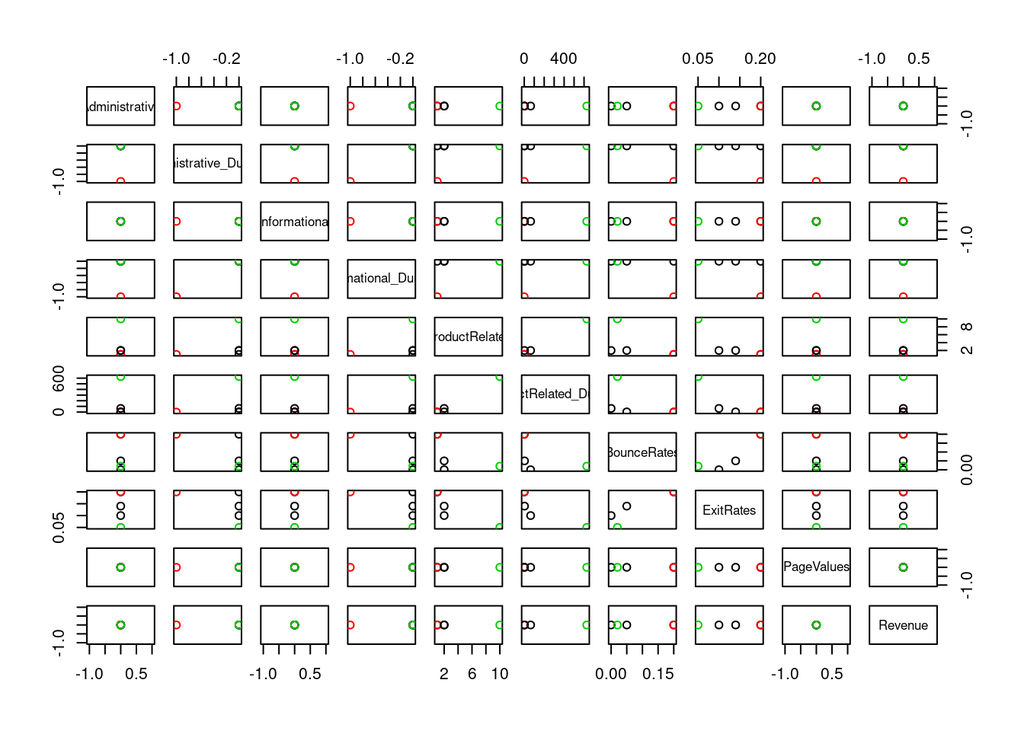

```r
plot(shopper[c(1,2,3,4,5)], col = clusters$cluster)
```

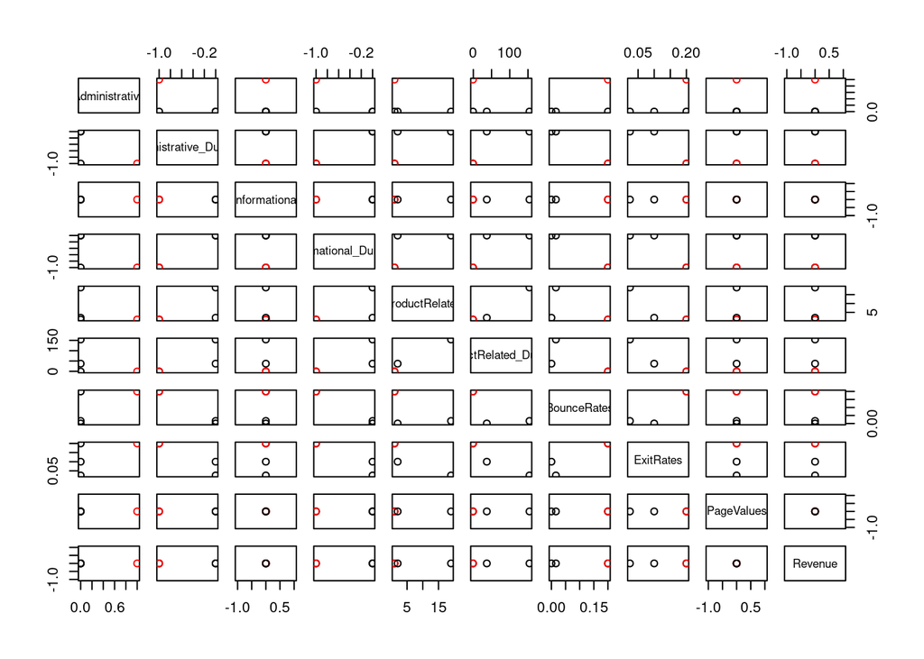

```r
plot(shopper[c(6,7,8,9)], col = clusters$cluster)
```

None of them seem to have that much of an impact.

Hierarchical Clustering

```r
shopper <- new_df[, c(1,2,3,4,5,6,7,8,9,18)]
shopper
```

```
##        Administrative Administrative_Duration Informational
##     1:              0                       0             0
##     2:              0                       0             0
##     3:              0                      -1             0
##     4:              0                       0             0
##     5:              0                       0             0
##    ---
## 12195:              3                     145             0
## 12196:              0                       0             0
## 12197:              0                       0             0
## 12198:              4                      75             0
## 12199:              0                       0             0
##        Informational_Duration ProductRelated ProductRelated_Duration
##     1:                      0              1                0.000000
##     2:                      0              2               64.000000
```

[output cut: 21 more lines]

```r
shopper <- new_df[, c(1,2,3,4,5,6,7,8,9,18)]
```

```r
df <- scale(shopper)
```

Lets commpute the Euclidean distance

```r
d <- dist(df, method = 'euclidean')
```

We then apply the Ward’s method for hierarchial clustering

```r
res.hc <- hclust(d, method = 'ward.D2' )
```

Let’s plot the dendrogram

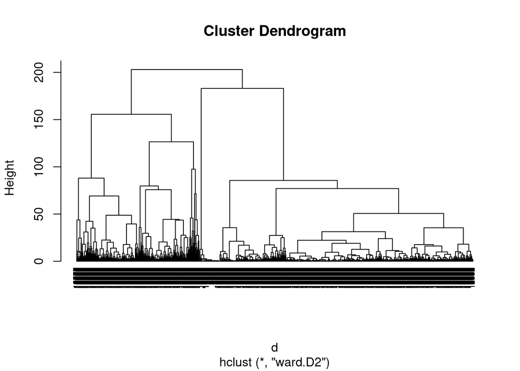

```r
plot(res.hc, cex =0.6, hang= -1)
```